# Documentazione

## 7.2 Dimensione

Il metodo di cambio di dimensioni, riduce i valori di `field$size.x` e `field$size.y` di un valore costante pari a numero di riga (o colonna) della matrice per $k=.9$. Se per esempio la regola è applicata orizzontalmente, gli elementi nelle celle `Sq1,Sq4,sq7`della prima colonna hanno dimensioni $(\frac{x}{k},\frac{y}{k})$, gli elementi nelle celle `Sq2,Sq5,sq8` hanno dimensioni $(\frac{x}{2k},\frac{y}{2k})$ e quelli nella terza colonna $(\frac{x}{3k},\frac{y}{3k})$.

```r
size.field<-function(obj,n,...) {
  obj$size.x[[1]]<-obj$size.x[[1]]/(n*.9)
  obj$size.y[[1]]<-obj$size.y[[1]]/(n*.9)
  return(obj)
}
```

La cambio di dimensione può essere applicata con le regole orizzontali, verticali e diagonalmente da basso a sinistra a alto-destra (TL-LR) applicando prima in orizzontale poi verticale.

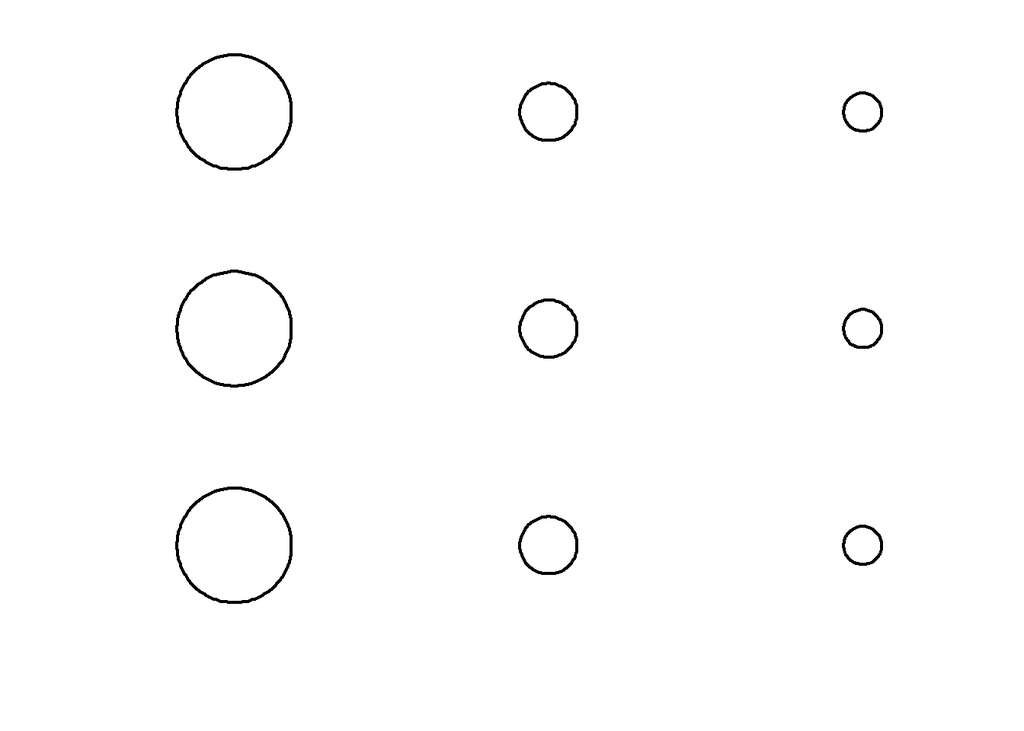

```r
#Horizontal
M<-apply(Raven(st1=circle(),hrule=c("size"),vrule=c("identity")))
draw(M)
```

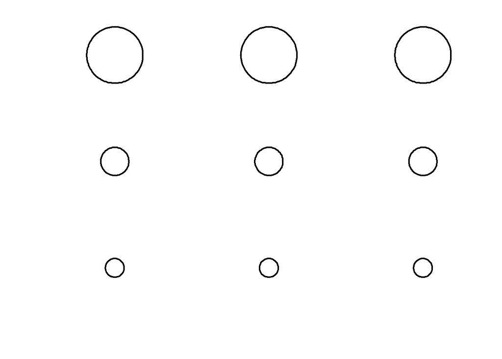

```r
#Vertical
M<-apply(Raven(st1=circle(),hrule=c("identity"),vrule=c("size")))
draw(M)
```

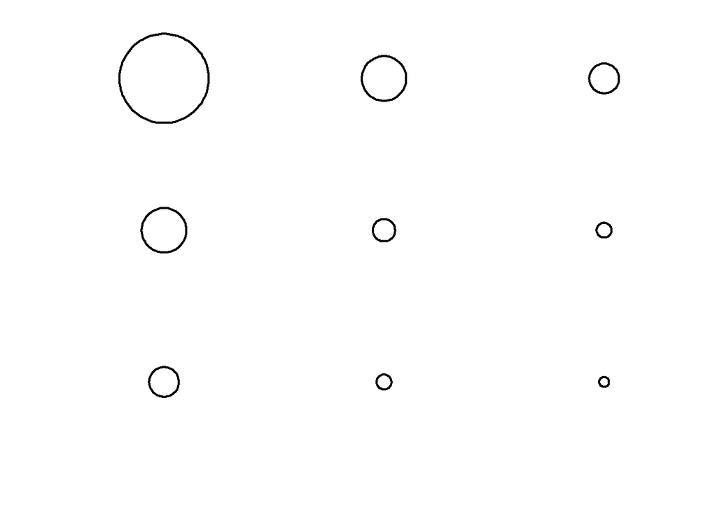

```r
# Top Left Low Right
M<-apply(Raven(st1=circle(),hrule=c("size"),vrule=c("size")))
draw(M)
```

## 7.3 Cambio delle forme

```r
diff_shapes.field<-function(obj,n,...) {
  if(length(obj$visible)!=3)
  {
    stop("You must have at least three forms to change shapes!")
  }
  #index<-c(3:1,3:1,3:1) TL-LR
  index<-c(1:3,1:3,1:3) #TR-LL
  pos<-which(obj$visible==1)
  if(length(pos)>1){
    obj$visible[pos]<-0
    obj$visible[index[n]]<-1
  }else {
    obj$visible[pos]<-0
    obj$visible[index[pos+n]]<-1
  }
  return(obj)
}
```

Il cambio di forma può essere applicato con le regole orizzontali, verticali e diagonalmente da basso a sinistra a alto-destra (TL-LR) applicando prima in orizzontale poi verticale.

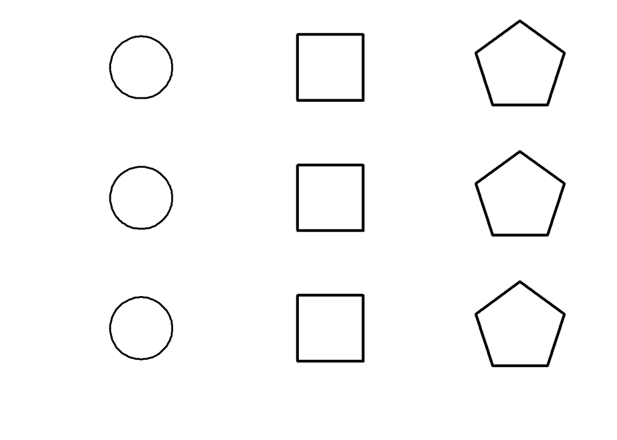

```r
#Horizontal
M<-apply(Raven(st1=cof(circle(),square(),pentagon()),hrule=c("diff_shapes"),vrule=c("identity")))
draw(M)
```

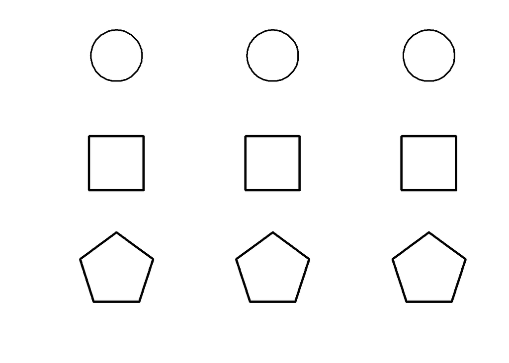

```r
#Vertical
M<-apply(Raven(st1=cof(circle(),square(),pentagon()),hrule=c("identity"),vrule=c("diff_shapes")))
draw(M)
```

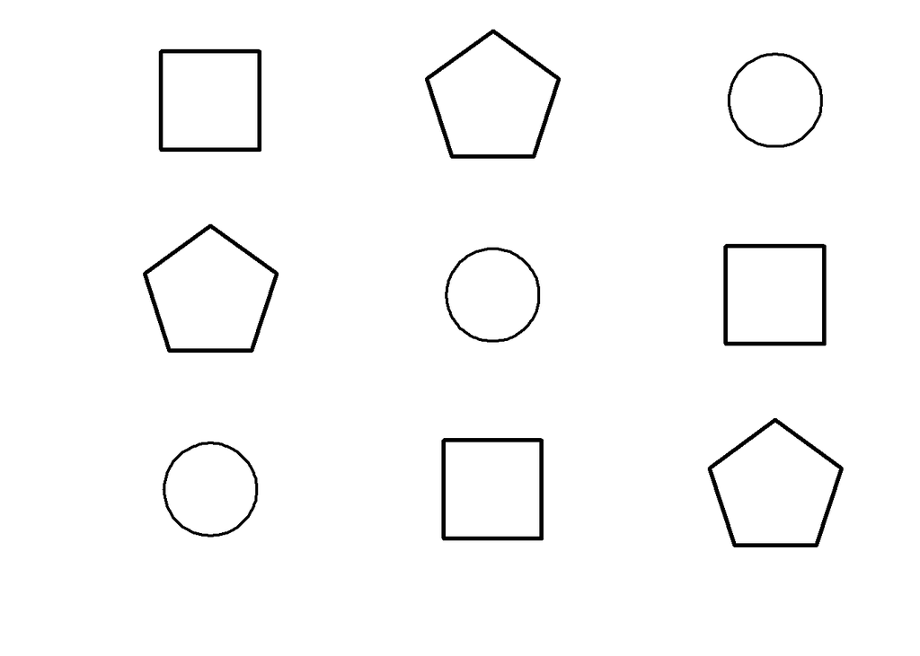

```r
# Top Left Low Right
M<-apply(Raven(st1=cof(circle(),square(),pentagon()),hrule=c("diff_shapes"),vrule=c("diff_shapes")))
draw(M)
```

## 7.4 Contorno

```r
margin.field<-function(obj,n,rules,...){
  index<-c(3:1,3:1,3:1)
  if(grepl("lwd",rules)){
    obj$lwd[[1]]<- index[obj$lwd[[1]]+n]+1
  }else if(grepl("lty",rules)){
    obj$lty[[1]]<-index[obj$lty[[1]]+n]
    }
  return(obj)
}
```

### 7.4.1 Spessore del contorno

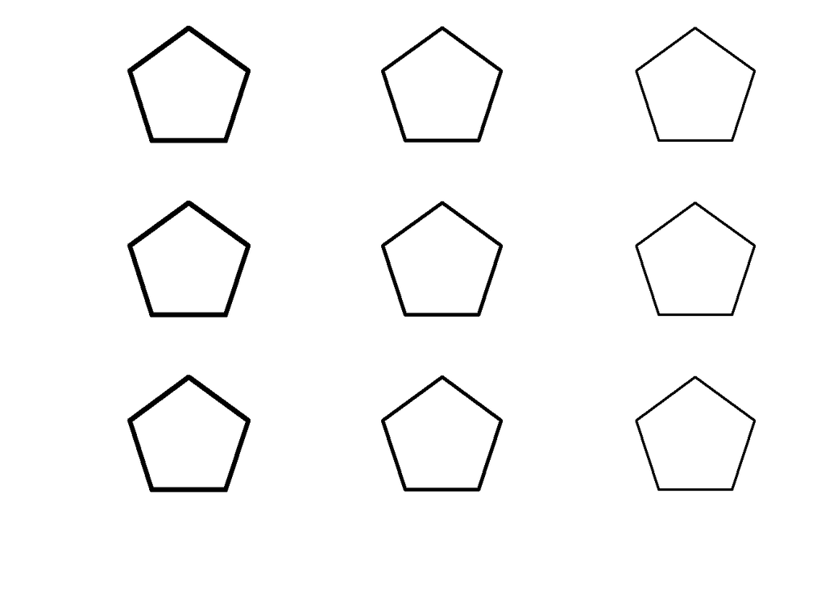

```r
#Horizontal
M<-apply(Raven(st1=pentagon(),hrule=c("lwd"),vrule=c("identity")))
draw(M)
```

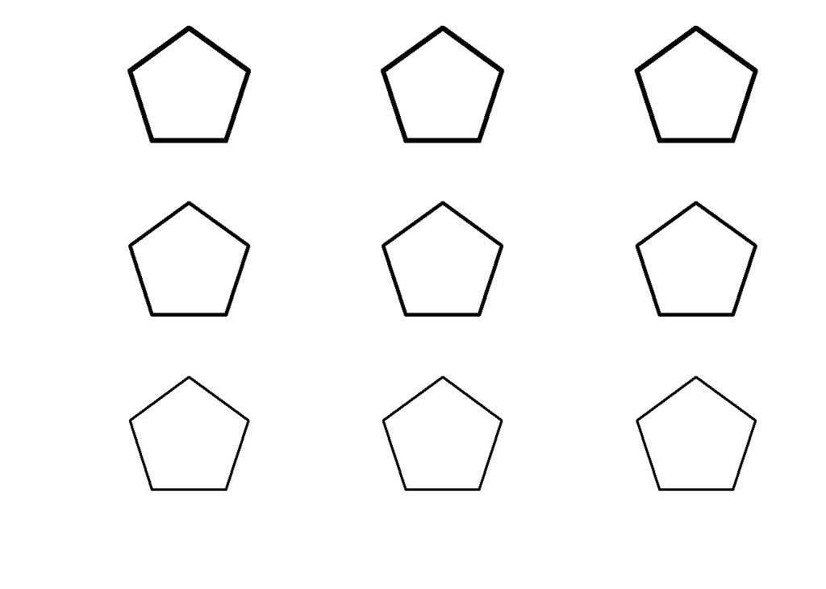

```r
#Vertical
M<-apply(Raven(st1=pentagon(),hrule=c("identity"),vrule=c("lwd")))
draw(M)
```

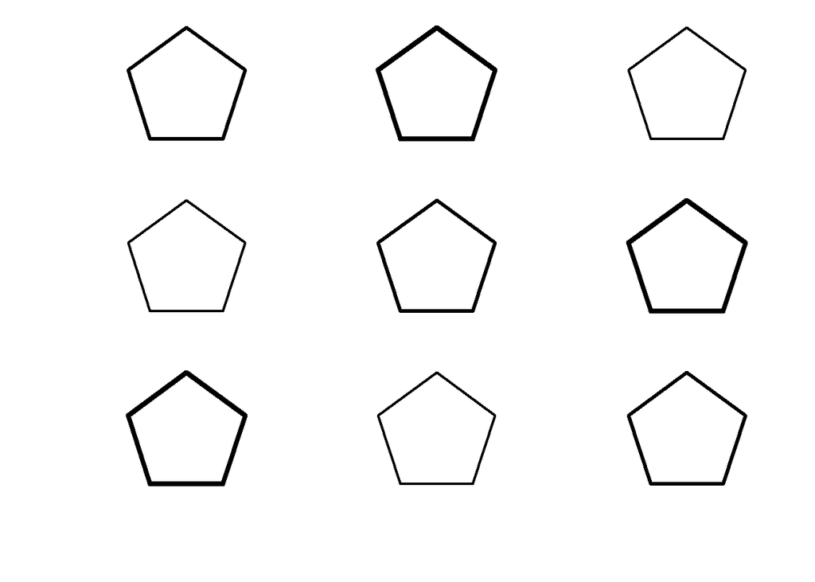

```r
# Top Left Low Right
M<-apply(Raven(st1=pentagon(),hrule=c("lwd"),vrule=c("lwd")))
draw(M)
```

### 7.4.2 Tipo del contorno

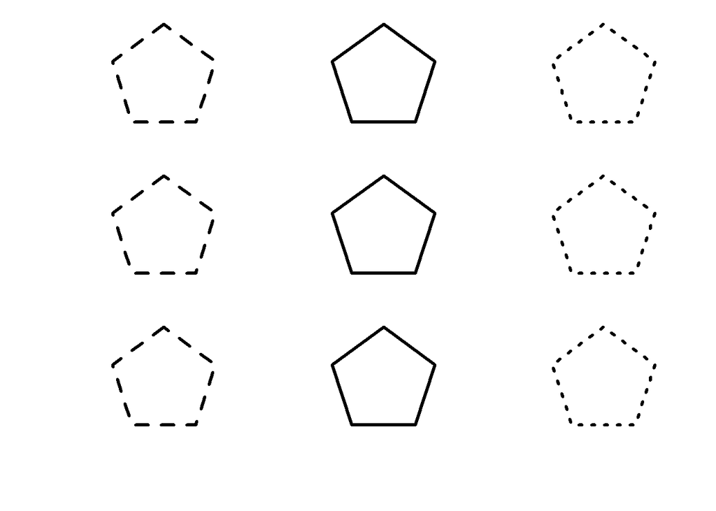

```r
#Horizontal
M<-apply(Raven(st1=pentagon(),hrule=c("lty"),vrule=c("identity")))
draw(M)
```

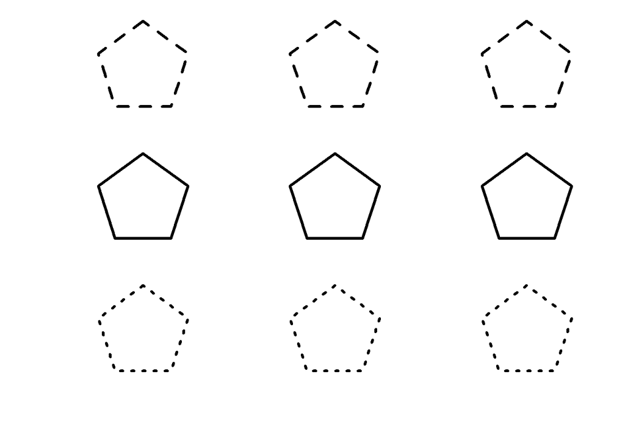

```r
#Vertical
M<-apply(Raven(st1=pentagon(),hrule=c("identity"),vrule=c("lty")))
draw(M)
```

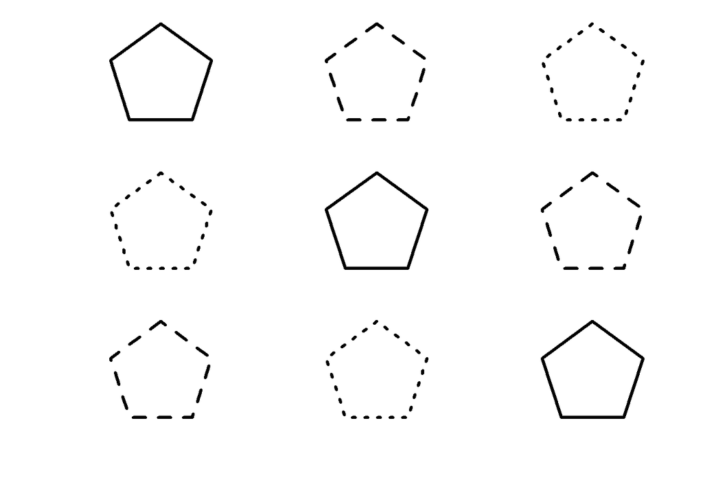

```r
# Top Left Low Right
M<-apply(Raven(st1=pentagon(),hrule=c("lty"),vrule=c("lty")))
draw(M)
```

## 7.5 Riempimento

Il riempimento monocromatico viene applicato campo per campo.

### 7.5.1 Riempimento monocromatico

La regola per il rimepimento monocromatico cambia il campo `field$shade` tra i valori `white`, `black` e `grey`. I tre diversi riempimenti vengono assegnati tramite l’indice di riga (o di colonna) $n$. Il solo perimentro si ottiene con `field$shade="none"`

```r
fill.field<-function(obj,n,...){
  index <- rep(c("white","grey","black"),3)
   pos <- index==obj$shade[[1]]
  if(is.na(sum(pos)))
  {
    obj$shade[[1]]<-index[n]
  }else{
    pos <- which(pos)
    obj$shade[[1]]<-index[pos+n]
  }
  return(obj)
}
```

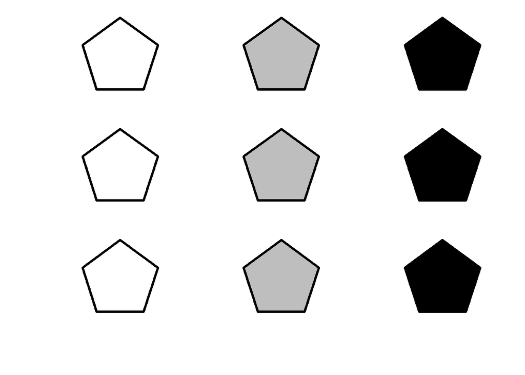

```r
#Horizontal
M<-apply(Raven(st1=pentagon(),hrule=c("fill"),vrule=c("identity")))
draw(M)
```

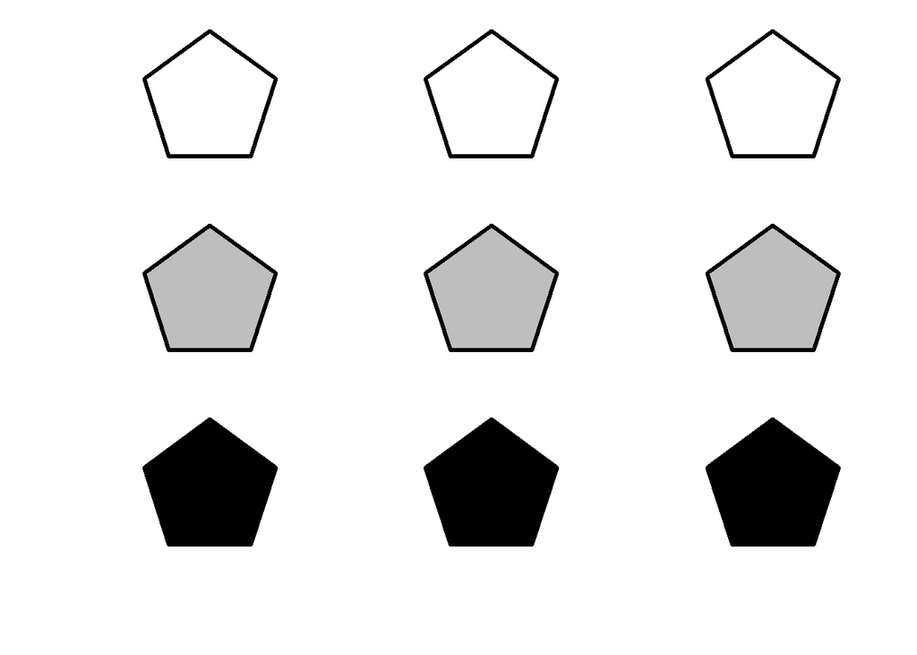

```r
#Vertical
M<-apply(Raven(st1=pentagon(),hrule=c("identity"),vrule=c("fill")))
draw(M)
```

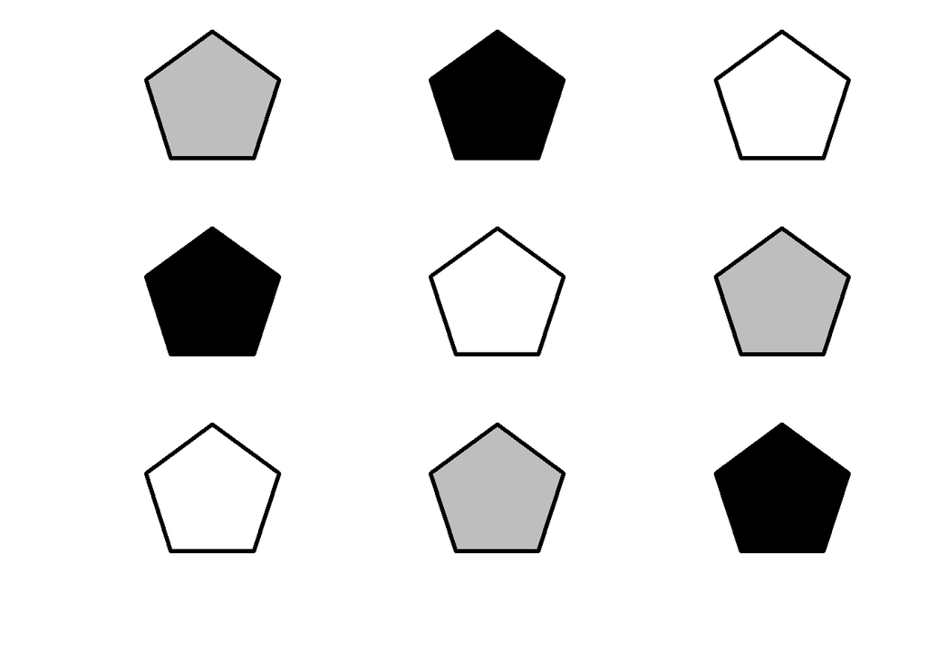

```r
# Top Left Low Right
M<-apply(Raven(st1=pentagon(),hrule=c("fill"),vrule=c("fill")))
draw(M)
```

## 7.6 Logica

Le regole logiche vengono applicate per riga e per colonna con 3 o più forme. Presento gli elementi basi per applicare la logica in termini insiemistici.

```r
logic.field<-function(obj,n,rule,seed,...) {
    if(length(obj$shape)<3)
    {
      stop("You must have three forms to apply a logical AND !")
    }
  ##gestione di più immagini
  domain<-1:length(obj$shape)
  obj$visible[domain]<-1
  set.seed(seed)
  fixed<-sample(domain,round(length(obj$shape)/5))
  domain<-setdiff(domain,fixed)
  half<-length(domain)%/%2
  index<-list()
  index[[1]]<-sample(domain,half)
  index[[2]]<-sample(setdiff(domain,index[[1]]),half)

  if(rule=="AND"){
    index[[3]]<-union(index[[1]],index[[2]])
    obj$visible[index[[n]]]<-0
  }else if(rule=="OR"){
    if(n<3){
      obj$visible[index[[n]]]<-0
    }
  }else if(rule=="XOR"){
    index[[3]]<-union(setdiff(domain,union(index[[1]],index[[2]])),fixed)
    obj$visible[index[[n]]]<-0
  }
  return(obj)
}
```

- `domain`è l’insieme delle forme $D$
- `fixed` è l’intersezione tra la prima e la seconda cella $C_1 \cap C_2$
- `index[[1]]` è l’insieme delle forme nella prima cella meno l’intersezione $C_1 / \{ C_1 \cap C_2\}$
- `index[[2]]` è l’insieme delle forme nella seconda cella meno l’intersezione $C_2 / \{ C_1 \cap C_2\}$

Questi insiemi vengono mantenuti costanti per riga (o per colonna) tramite dei differenti semi.

### 7.6.1 AND

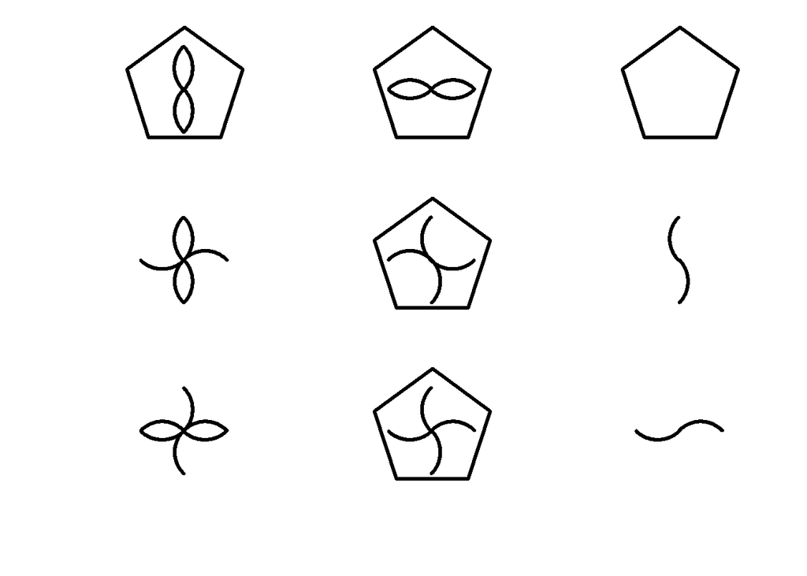

```r
#Horizontal
M<-apply(Raven(st1=cof(pentagon(),vertical.eight(),horizontal.eight()),hrule=c("AND"),vrule=c("identity")))
draw(M)
```

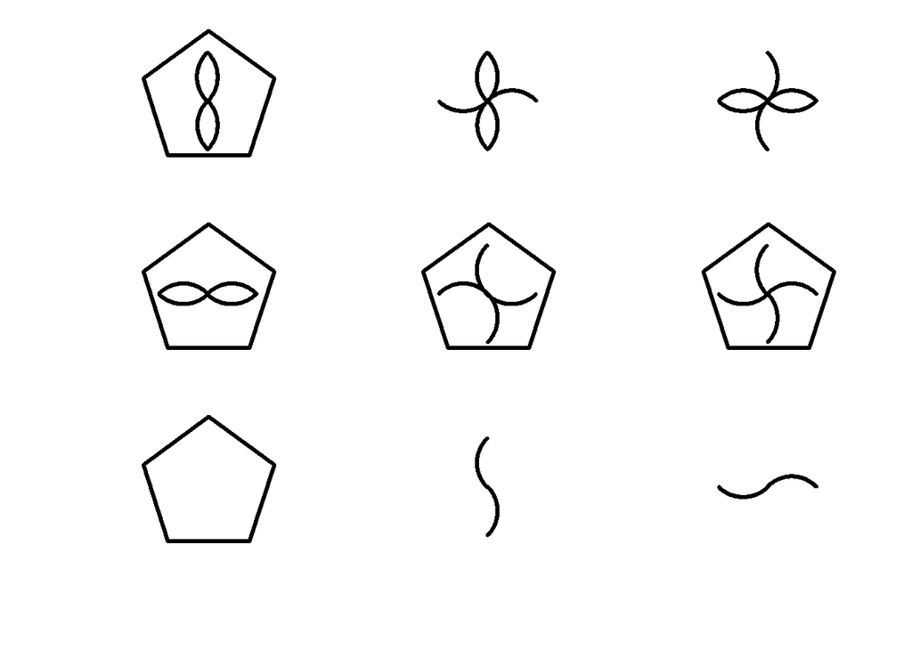

```r
#Vertical
M<-apply(Raven(st1=cof(pentagon(),vertical.eight(),horizontal.eight()),vrule=c("AND"),hrule=c("identity")))
draw(M)
```

### 7.6.2 OR

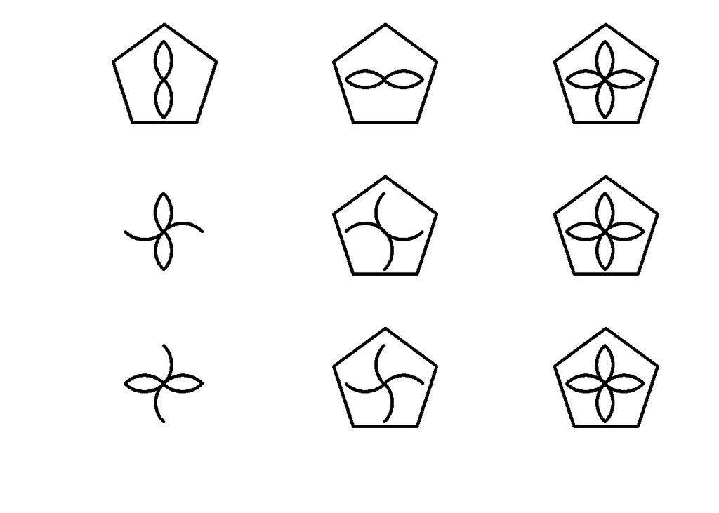

```r
#Horizontal
M<-apply(Raven(st1=cof(pentagon(),vertical.eight(),horizontal.eight()),hrule=c("OR"),vrule=c("identity")))
draw(M)
```

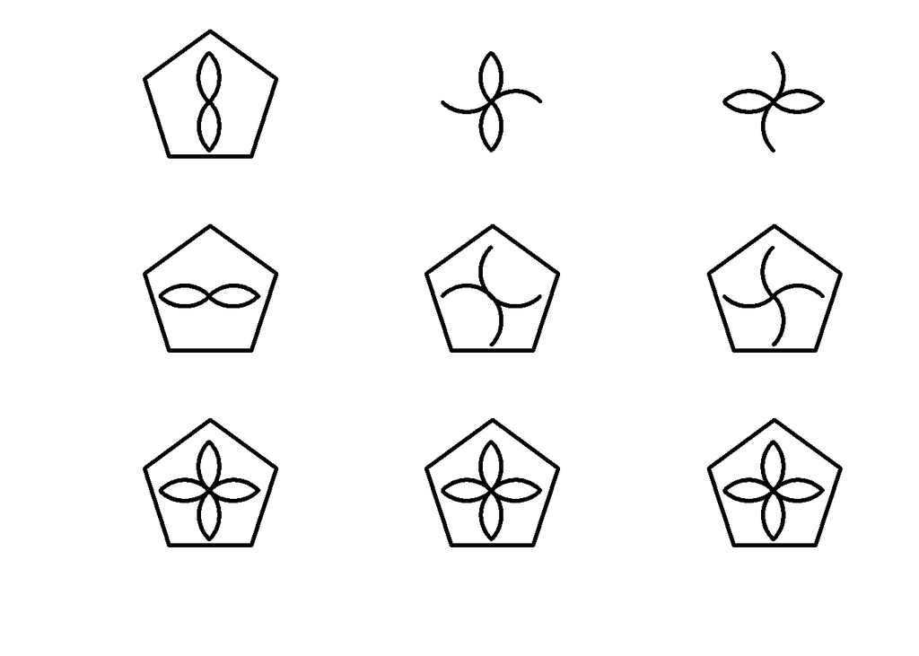

```r
#Vertical
M<-apply(Raven(st1=cof(pentagon(),vertical.eight(),horizontal.eight()),vrule=c("OR"),hrule=c("identity")))
draw(M)
```

### 7.6.3 Xor

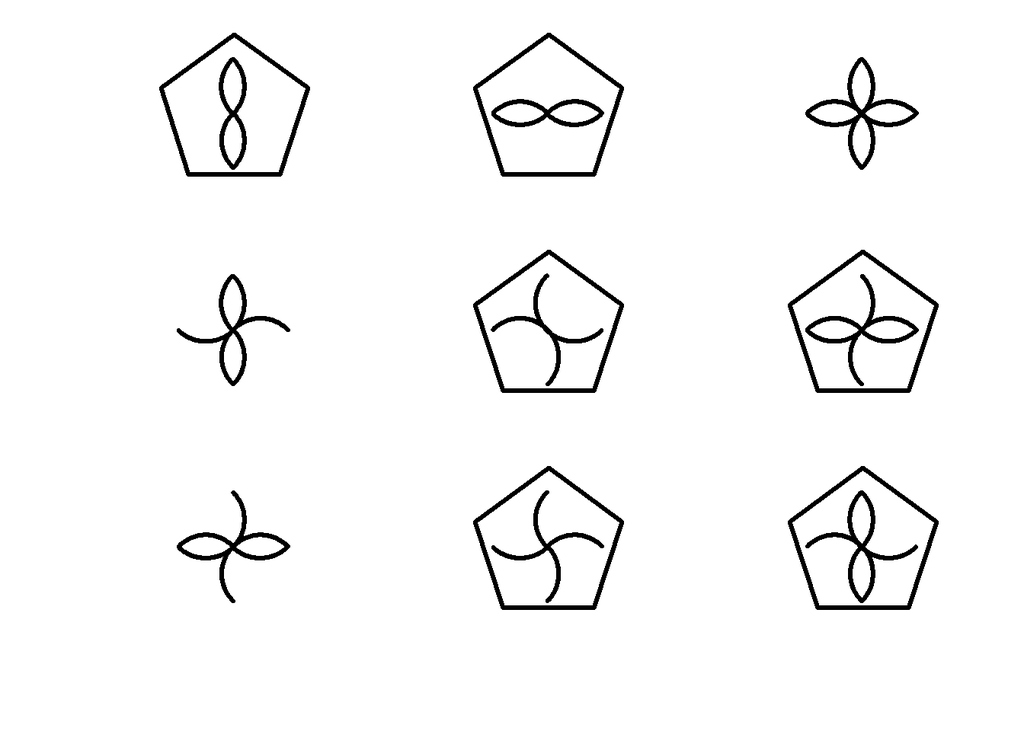

```r
#Horizontal
M<-apply(Raven(st1=cof(pentagon(),vertical.eight(),horizontal.eight()),hrule=c("XOR"),vrule=c("identity")))
draw(M)
```

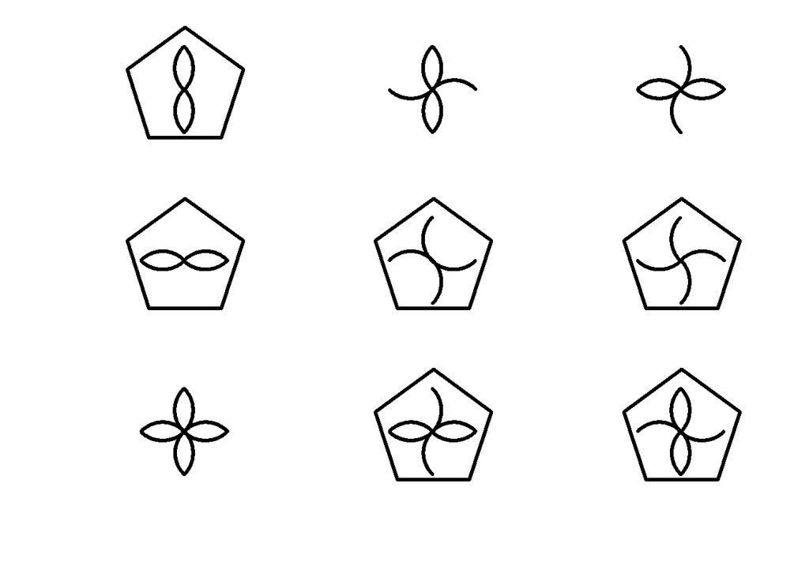

```r
#Vertical
M<-apply(Raven(st1=cof(pentagon(),vertical.eight(),horizontal.eight()),vrule=c("XOR"),hrule=c("identity")))
draw(M)
```

# 8 Regole (Raven)

## 8.1 Riempimento con altre forme

## 8.2 Logica

### 8.2.1 AND

### 8.2.2 OR

### 8.2.3 XOR